# Risk Factor Analysis

## Outcome Variable

**Outcome Variable:** ever_sstunted

## Predictor Variables

**Intervention Variable:** nchldlt5

**Adjustment Set:**

unadjusted

## Stratifying Variables

The analysis was stratified on these variable(s):

- agecat
- studyid
- country

## Data Summary

| agecat | studyid | country | nchldlt5 | ever_sstunted | n_cell | n |
| --- | --- | --- | --- | --- | --- | --- |
| 0-24 months | iLiNS-Zinc | BURKINA FASO | 1 | 0 | 977 | 3188 |
| 0-24 months | iLiNS-Zinc | BURKINA FASO | 1 | 1 | 96 | 3188 |
| 0-24 months | iLiNS-Zinc | BURKINA FASO | 2+ | 0 | 1879 | 3188 |
| 0-24 months | iLiNS-Zinc | BURKINA FASO | 2+ | 1 | 236 | 3188 |
| 0-24 months | IRC | INDIA | 1 | 0 | 64 | 410 |
| 0-24 months | IRC | INDIA | 1 | 1 | 25 | 410 |
| 0-24 months | IRC | INDIA | 2+ | 0 | 244 | 410 |
| 0-24 months | IRC | INDIA | 2+ | 1 | 77 | 410 |
| 0-24 months | JiVitA-3 | BANGLADESH | 1 | 0 | 13936 | 27200 |
| 0-24 months | JiVitA-3 | BANGLADESH | 1 | 1 | 3474 | 27200 |
| 0-24 months | JiVitA-3 | BANGLADESH | 2+ | 0 | 8244 | 27200 |
| 0-24 months | JiVitA-3 | BANGLADESH | 2+ | 1 | 1546 | 27200 |
| 0-24 months | LCNI-5 | MALAWI | 1 | 0 | 327 | 812 |
| 0-24 months | LCNI-5 | MALAWI | 1 | 1 | 64 | 812 |
| 0-24 months | LCNI-5 | MALAWI | 2+ | 0 | 315 | 812 |
| 0-24 months | LCNI-5 | MALAWI | 2+ | 1 | 106 | 812 |
| 0-24 months | NIH-Crypto | BANGLADESH | 1 | 0 | 475 | 758 |
| 0-24 months | NIH-Crypto | BANGLADESH | 1 | 1 | 66 | 758 |
| 0-24 months | NIH-Crypto | BANGLADESH | 2+ | 0 | 184 | 758 |
| 0-24 months | NIH-Crypto | BANGLADESH | 2+ | 1 | 33 | 758 |
| 0-24 months | PROVIDE | BANGLADESH | 1 | 0 | 442 | 700 |
| 0-24 months | PROVIDE | BANGLADESH | 1 | 1 | 70 | 700 |
| 0-24 months | PROVIDE | BANGLADESH | 2+ | 0 | 163 | 700 |
| 0-24 months | PROVIDE | BANGLADESH | 2+ | 1 | 25 | 700 |
| 0-24 months | TanzaniaChild2 | TANZANIA, UNITED REPUBLIC OF | 1 | 0 | 1479 | 2385 |
| 0-24 months | TanzaniaChild2 | TANZANIA, UNITED REPUBLIC OF | 1 | 1 | 158 | 2385 |
| 0-24 months | TanzaniaChild2 | TANZANIA, UNITED REPUBLIC OF | 2+ | 0 | 669 | 2385 |
| 0-24 months | TanzaniaChild2 | TANZANIA, UNITED REPUBLIC OF | 2+ | 1 | 79 | 2385 |
| 0-6 months | IRC | INDIA | 1 | 0 | 68 | 410 |
| 0-6 months | IRC | INDIA | 1 | 1 | 21 | 410 |
| 0-6 months | IRC | INDIA | 2+ | 0 | 280 | 410 |
| 0-6 months | IRC | INDIA | 2+ | 1 | 41 | 410 |
| 0-6 months | JiVitA-3 | BANGLADESH | 1 | 0 | 14467 | 27134 |
| 0-6 months | JiVitA-3 | BANGLADESH | 1 | 1 | 2892 | 27134 |
| 0-6 months | JiVitA-3 | BANGLADESH | 2+ | 0 | 8665 | 27134 |
| 0-6 months | JiVitA-3 | BANGLADESH | 2+ | 1 | 1110 | 27134 |
| 0-6 months | LCNI-5 | MALAWI | 1 | 0 | 111 | 267 |
| 0-6 months | LCNI-5 | MALAWI | 1 | 1 | 11 | 267 |
| 0-6 months | LCNI-5 | MALAWI | 2+ | 0 | 137 | 267 |
| 0-6 months | LCNI-5 | MALAWI | 2+ | 1 | 8 | 267 |
| 0-6 months | NIH-Crypto | BANGLADESH | 1 | 0 | 506 | 758 |
| 0-6 months | NIH-Crypto | BANGLADESH | 1 | 1 | 35 | 758 |
| 0-6 months | NIH-Crypto | BANGLADESH | 2+ | 0 | 205 | 758 |
| 0-6 months | NIH-Crypto | BANGLADESH | 2+ | 1 | 12 | 758 |
| 0-6 months | PROVIDE | BANGLADESH | 1 | 0 | 488 | 700 |
| 0-6 months | PROVIDE | BANGLADESH | 1 | 1 | 24 | 700 |
| 0-6 months | PROVIDE | BANGLADESH | 2+ | 0 | 181 | 700 |
| 0-6 months | PROVIDE | BANGLADESH | 2+ | 1 | 7 | 700 |
| 0-6 months | TanzaniaChild2 | TANZANIA, UNITED REPUBLIC OF | 1 | 0 | 1564 | 2385 |
| 0-6 months | TanzaniaChild2 | TANZANIA, UNITED REPUBLIC OF | 1 | 1 | 73 | 2385 |
| 0-6 months | TanzaniaChild2 | TANZANIA, UNITED REPUBLIC OF | 2+ | 0 | 718 | 2385 |
| 0-6 months | TanzaniaChild2 | TANZANIA, UNITED REPUBLIC OF | 2+ | 1 | 30 | 2385 |

The following strata were considered:

- agecat: 0-24 months, studyid: iLiNS-Zinc, country: BURKINA FASO
- agecat: 0-24 months, studyid: IRC, country: INDIA
- agecat: 0-24 months, studyid: JiVitA-3, country: BANGLADESH
- agecat: 0-24 months, studyid: LCNI-5, country: MALAWI
- agecat: 0-24 months, studyid: NIH-Crypto, country: BANGLADESH
- agecat: 0-24 months, studyid: PROVIDE, country: BANGLADESH
- agecat: 0-24 months, studyid: TanzaniaChild2, country: TANZANIA, UNITED REPUBLIC OF
- agecat: 0-6 months, studyid: IRC, country: INDIA
- agecat: 0-6 months, studyid: JiVitA-3, country: BANGLADESH
- agecat: 0-6 months, studyid: LCNI-5, country: MALAWI
- agecat: 0-6 months, studyid: NIH-Crypto, country: BANGLADESH
- agecat: 0-6 months, studyid: PROVIDE, country: BANGLADESH
- agecat: 0-6 months, studyid: TanzaniaChild2, country: TANZANIA, UNITED REPUBLIC OF

## Methods Detail

We’re interested in the causal parameters $E[Y_a]$ for all values of $a \in \mathcal{A}$. These parameters represent the mean outcome if, possibly contrary to fact, we intervened to set all units to have $A=a$. Under the randomization and positivity assumptions, these are identified by the statistical parameters $\psi_a=E_W[E_{Y|A,W}(Y|A=a,W)]$. In addition, we’re interested in the mean of $Y$, $E[Y]$ under no intervention (the observed mean). We will estimate these parameters by using SuperLearner to fit the relevant likelihood factors – $E_{Y|A,W}(Y|A=a,W)$ and $p(A=a|W)$, and then updating our likelihood fit using a joint TMLE.

For unadjusted analyses ($W=\{\}$), initial likelihoods were estimated using Lrnr_glm to estimate the simple $E(Y|A)$ and Lrnr_mean to estimate $p(A)$. For adjusted analyses, a small library containing Lrnr_glmnet, Lrnr_xgboost, and Lrnr_mean was used.

Having estimated these parameters, we will then use the delta method to estimate relative risks and attributable risks relative to a prespecified baseline level of $A$.

# Results Detail

## Results Plots

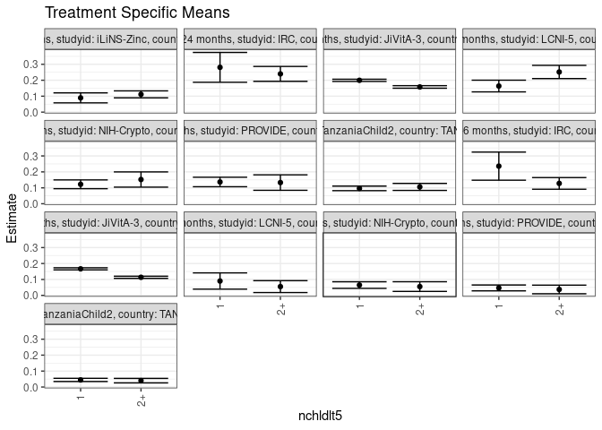

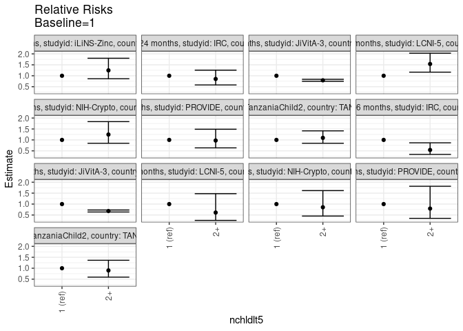

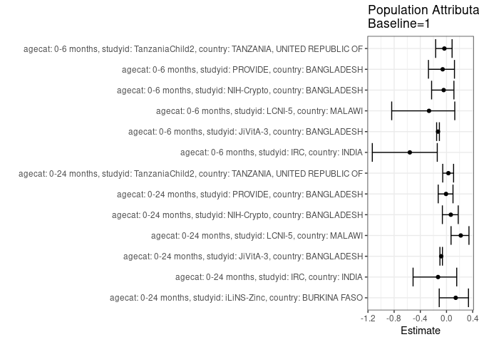

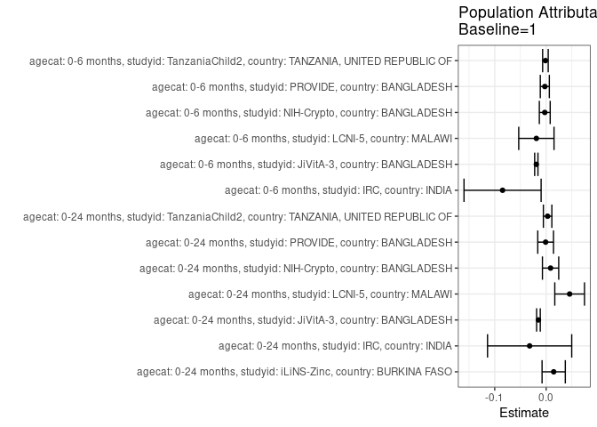

## Results Table

### Parameter: TSM

| agecat | studyid | country | intervention_level | baseline_level | estimate | ci_lower | ci_upper |
| --- | --- | --- | --- | --- | --- | --- | --- |
| 0-24 months | iLiNS-Zinc | BURKINA FASO | 1 | NA | 0.0894688 | 0.0580976 | 0.1208400 |
| 0-24 months | iLiNS-Zinc | BURKINA FASO | 2+ | NA | 0.1115839 | 0.0897094 | 0.1334585 |
| 0-24 months | IRC | INDIA | 1 | NA | 0.2808989 | 0.1874114 | 0.3743863 |
| 0-24 months | IRC | INDIA | 2+ | NA | 0.2398754 | 0.1931061 | 0.2866447 |
| 0-24 months | JiVitA-3 | BANGLADESH | 1 | NA | 0.1995405 | 0.1925866 | 0.2064944 |
| 0-24 months | JiVitA-3 | BANGLADESH | 2+ | NA | 0.1579162 | 0.1499577 | 0.1658748 |
| 0-24 months | LCNI-5 | MALAWI | 1 | NA | 0.1636829 | 0.1269872 | 0.2003785 |
| 0-24 months | LCNI-5 | MALAWI | 2+ | NA | 0.2517815 | 0.2102956 | 0.2932674 |
| 0-24 months | NIH-Crypto | BANGLADESH | 1 | NA | 0.1219963 | 0.0943996 | 0.1495930 |
| 0-24 months | NIH-Crypto | BANGLADESH | 2+ | NA | 0.1520737 | 0.1042646 | 0.1998829 |
| 0-24 months | PROVIDE | BANGLADESH | 1 | NA | 0.1367187 | 0.1069395 | 0.1664980 |
| 0-24 months | PROVIDE | BANGLADESH | 2+ | NA | 0.1329787 | 0.0844068 | 0.1815507 |
| 0-24 months | TanzaniaChild2 | TANZANIA, UNITED REPUBLIC OF | 1 | NA | 0.0965180 | 0.0822100 | 0.1108260 |
| 0-24 months | TanzaniaChild2 | TANZANIA, UNITED REPUBLIC OF | 2+ | NA | 0.1056150 | 0.0835850 | 0.1276449 |
| 0-6 months | IRC | INDIA | 1 | NA | 0.2359551 | 0.1476354 | 0.3242747 |
| 0-6 months | IRC | INDIA | 2+ | NA | 0.1277259 | 0.0911671 | 0.1642846 |
| 0-6 months | JiVitA-3 | BANGLADESH | 1 | NA | 0.1665995 | 0.1601089 | 0.1730900 |
| 0-6 months | JiVitA-3 | BANGLADESH | 2+ | NA | 0.1135550 | 0.1068339 | 0.1202761 |
| 0-6 months | LCNI-5 | MALAWI | 1 | NA | 0.0901639 | 0.0392448 | 0.1410831 |
| 0-6 months | LCNI-5 | MALAWI | 2+ | NA | 0.0551724 | 0.0179404 | 0.0924044 |
| 0-6 months | NIH-Crypto | BANGLADESH | 1 | NA | 0.0646950 | 0.0439531 | 0.0854369 |
| 0-6 months | NIH-Crypto | BANGLADESH | 2+ | NA | 0.0552995 | 0.0248688 | 0.0857303 |
| 0-6 months | PROVIDE | BANGLADESH | 1 | NA | 0.0468750 | 0.0285532 | 0.0651968 |
| 0-6 months | PROVIDE | BANGLADESH | 2+ | NA | 0.0372340 | 0.0101502 | 0.0643179 |
| 0-6 months | TanzaniaChild2 | TANZANIA, UNITED REPUBLIC OF | 1 | NA | 0.0445938 | 0.0345927 | 0.0545948 |
| 0-6 months | TanzaniaChild2 | TANZANIA, UNITED REPUBLIC OF | 2+ | NA | 0.0401070 | 0.0260429 | 0.0541710 |

### Parameter: E(Y)

| agecat | studyid | country | intervention_level | baseline_level | estimate | ci_lower | ci_upper |
| --- | --- | --- | --- | --- | --- | --- | --- |
| 0-24 months | iLiNS-Zinc | BURKINA FASO | NA | NA | 0.1041405 | 0.0842158 | 0.1240653 |
| 0-24 months | IRC | INDIA | NA | NA | 0.2487805 | 0.2068840 | 0.2906770 |
| 0-24 months | JiVitA-3 | BANGLADESH | NA | NA | 0.1845588 | 0.1789526 | 0.1901651 |
| 0-24 months | LCNI-5 | MALAWI | NA | NA | 0.2093596 | 0.1813586 | 0.2373606 |
| 0-24 months | NIH-Crypto | BANGLADESH | NA | NA | 0.1306069 | 0.1066024 | 0.1546113 |
| 0-24 months | PROVIDE | BANGLADESH | NA | NA | 0.1357143 | 0.1103250 | 0.1611036 |
| 0-24 months | TanzaniaChild2 | TANZANIA, UNITED REPUBLIC OF | NA | NA | 0.0993711 | 0.0873623 | 0.1113798 |
| 0-6 months | IRC | INDIA | NA | NA | 0.1512195 | 0.1164988 | 0.1859402 |
| 0-6 months | JiVitA-3 | BANGLADESH | NA | NA | 0.1474902 | 0.1424375 | 0.1525429 |
| 0-6 months | LCNI-5 | MALAWI | NA | NA | 0.0711610 | 0.0402653 | 0.1020568 |
| 0-6 months | NIH-Crypto | BANGLADESH | NA | NA | 0.0620053 | 0.0448256 | 0.0791849 |
| 0-6 months | PROVIDE | BANGLADESH | NA | NA | 0.0442857 | 0.0290345 | 0.0595370 |
| 0-6 months | TanzaniaChild2 | TANZANIA, UNITED REPUBLIC OF | NA | NA | 0.0431866 | 0.0350267 | 0.0513464 |

### Parameter: RR

| agecat | studyid | country | intervention_level | baseline_level | estimate | ci_lower | ci_upper |
| --- | --- | --- | --- | --- | --- | --- | --- |
| 0-24 months | iLiNS-Zinc | BURKINA FASO | 1 | 1 | 1.0000000 | 1.0000000 | 1.0000000 |
| 0-24 months | iLiNS-Zinc | BURKINA FASO | 2+ | 1 | 1.2471828 | 0.8641056 | 1.8000866 |
| 0-24 months | IRC | INDIA | 1 | 1 | 1.0000000 | 1.0000000 | 1.0000000 |
| 0-24 months | IRC | INDIA | 2+ | 1 | 0.8539564 | 0.5806564 | 1.2558917 |
| 0-24 months | JiVitA-3 | BANGLADESH | 1 | 1 | 1.0000000 | 1.0000000 | 1.0000000 |
| 0-24 months | JiVitA-3 | BANGLADESH | 2+ | 1 | 0.7913995 | 0.7473755 | 0.8380166 |
| 0-24 months | LCNI-5 | MALAWI | 1 | 1 | 1.0000000 | 1.0000000 | 1.0000000 |
| 0-24 months | LCNI-5 | MALAWI | 2+ | 1 | 1.5382274 | 1.1646330 | 2.0316646 |
| 0-24 months | NIH-Crypto | BANGLADESH | 1 | 1 | 1.0000000 | 1.0000000 | 1.0000000 |
| 0-24 months | NIH-Crypto | BANGLADESH | 2+ | 1 | 1.2465438 | 0.8462573 | 1.8361691 |
| 0-24 months | PROVIDE | BANGLADESH | 1 | 1 | 1.0000000 | 1.0000000 | 1.0000000 |
| 0-24 months | PROVIDE | BANGLADESH | 2+ | 1 | 0.9726444 | 0.6357109 | 1.4881563 |
| 0-24 months | TanzaniaChild2 | TANZANIA, UNITED REPUBLIC OF | 1 | 1 | 1.0000000 | 1.0000000 | 1.0000000 |
| 0-24 months | TanzaniaChild2 | TANZANIA, UNITED REPUBLIC OF | 2+ | 1 | 1.0942513 | 0.8471915 | 1.4133593 |
| 0-6 months | IRC | INDIA | 1 | 1 | 1.0000000 | 1.0000000 | 1.0000000 |
| 0-6 months | IRC | INDIA | 2+ | 1 | 0.5413143 | 0.3379158 | 0.8671427 |
| 0-6 months | JiVitA-3 | BANGLADESH | 1 | 1 | 1.0000000 | 1.0000000 | 1.0000000 |
| 0-6 months | JiVitA-3 | BANGLADESH | 2+ | 1 | 0.6816048 | 0.6374641 | 0.7288019 |
| 0-6 months | LCNI-5 | MALAWI | 1 | 1 | 1.0000000 | 1.0000000 | 1.0000000 |
| 0-6 months | LCNI-5 | MALAWI | 2+ | 1 | 0.6119122 | 0.2538214 | 1.4751968 |
| 0-6 months | NIH-Crypto | BANGLADESH | 1 | 1 | 1.0000000 | 1.0000000 | 1.0000000 |
| 0-6 months | NIH-Crypto | BANGLADESH | 2+ | 1 | 0.8547729 | 0.4521261 | 1.6160020 |
| 0-6 months | PROVIDE | BANGLADESH | 1 | 1 | 1.0000000 | 1.0000000 | 1.0000000 |
| 0-6 months | PROVIDE | BANGLADESH | 2+ | 1 | 0.7943262 | 0.3478373 | 1.8139348 |
| 0-6 months | TanzaniaChild2 | TANZANIA, UNITED REPUBLIC OF | 1 | 1 | 1.0000000 | 1.0000000 | 1.0000000 |
| 0-6 months | TanzaniaChild2 | TANZANIA, UNITED REPUBLIC OF | 2+ | 1 | 0.8993847 | 0.5931597 | 1.3637015 |

### Parameter: PAR

| agecat | studyid | country | intervention_level | baseline_level | estimate | ci_lower | ci_upper |
| --- | --- | --- | --- | --- | --- | --- | --- |
| 0-24 months | iLiNS-Zinc | BURKINA FASO | 1 | NA | 0.0146717 | -0.0079278 | 0.0372713 |
| 0-24 months | IRC | INDIA | 1 | NA | -0.0321184 | -0.1139770 | 0.0497402 |
| 0-24 months | JiVitA-3 | BANGLADESH | 1 | NA | -0.0149817 | -0.0185292 | -0.0114341 |
| 0-24 months | LCNI-5 | MALAWI | 1 | NA | 0.0456767 | 0.0168010 | 0.0745524 |
| 0-24 months | NIH-Crypto | BANGLADESH | 1 | NA | 0.0086106 | -0.0072224 | 0.0244435 |
| 0-24 months | PROVIDE | BANGLADESH | 1 | NA | -0.0010045 | -0.0163065 | 0.0142976 |
| 0-24 months | TanzaniaChild2 | TANZANIA, UNITED REPUBLIC OF | 1 | NA | 0.0028530 | -0.0053872 | 0.0110933 |
| 0-6 months | IRC | INDIA | 1 | NA | -0.0847355 | -0.1596981 | -0.0097730 |
| 0-6 months | JiVitA-3 | BANGLADESH | 1 | NA | -0.0191092 | -0.0222944 | -0.0159241 |
| 0-6 months | LCNI-5 | MALAWI | 1 | NA | -0.0190029 | -0.0533233 | 0.0153176 |
| 0-6 months | NIH-Crypto | BANGLADESH | 1 | NA | -0.0026897 | -0.0132370 | 0.0078575 |
| 0-6 months | PROVIDE | BANGLADESH | 1 | NA | -0.0025893 | -0.0113770 | 0.0061984 |
| 0-6 months | TanzaniaChild2 | TANZANIA, UNITED REPUBLIC OF | 1 | NA | -0.0014072 | -0.0068202 | 0.0040058 |

### Parameter: PAF

| agecat | studyid | country | intervention_level | baseline_level | estimate | ci_lower | ci_upper |
| --- | --- | --- | --- | --- | --- | --- | --- |
| 0-24 months | iLiNS-Zinc | BURKINA FASO | 1 | NA | 0.1408841 | -0.1110611 | 0.3356980 |
| 0-24 months | IRC | INDIA | 1 | NA | -0.1291033 | -0.5108613 | 0.1561937 |
| 0-24 months | JiVitA-3 | BANGLADESH | 1 | NA | -0.0811756 | -0.1004558 | -0.0622331 |
| 0-24 months | LCNI-5 | MALAWI | 1 | NA | 0.2181736 | 0.0695052 | 0.3430887 |
| 0-24 months | NIH-Crypto | BANGLADESH | 1 | NA | 0.0659273 | -0.0630201 | 0.1792330 |
| 0-24 months | PROVIDE | BANGLADESH | 1 | NA | -0.0074013 | -0.1266990 | 0.0992648 |
| 0-24 months | TanzaniaChild2 | TANZANIA, UNITED REPUBLIC OF | 1 | NA | 0.0287111 | -0.0577938 | 0.1081417 |
| 0-6 months | IRC | INDIA | 1 | NA | -0.5603480 | -1.1336207 | -0.1411053 |
| 0-6 months | JiVitA-3 | BANGLADESH | 1 | NA | -0.1295626 | -0.1509194 | -0.1086022 |
| 0-6 months | LCNI-5 | MALAWI | 1 | NA | -0.2670406 | -0.8374155 | 0.1262772 |
| 0-6 months | NIH-Crypto | BANGLADESH | 1 | NA | -0.0433791 | -0.2277019 | 0.1132702 |
| 0-6 months | PROVIDE | BANGLADESH | 1 | NA | -0.0584677 | -0.2756059 | 0.1217084 |
| 0-6 months | TanzaniaChild2 | TANZANIA, UNITED REPUBLIC OF | 1 | NA | -0.0325839 | -0.1656942 | 0.0853266 |